# ENVS2018 Environmental Science Field School: Kioloa analyses

Shoshana Rapley, Saul Cunningham

20 September 2023

# 1 **Background**

For the Kioloa week the report will focus on biodiversity. In particular, you should examine the composition and structure of different plant communities at Kioloa, whether animal communities also differ, and how these patterns relate to the underlying soils and geology.

The reports must use our field collected data. We will work together to collect and summarise the data during the field trip and will share the summarised data so that all students are working with the same information. We do not ask you to conduct any additional statistical analyses. Rather, the task is to describe and patterns in the data that we have shared and indicate what processes have influenced the development of these patterns.

# 2 **Setup**

This document is called a ‘markdown’. It’s a way to share code, annotations and results all in one place, how good! For those of you interested in coding, we will include some notes on how we produced the results. Notes in the code itself that start with a hash and are in green font explain what the next line of code achieves.

Code note: First, we installed the [pacman Package Management Tool](https://cran.r-project.org/web/packages/pacman/index.html), which allows us to install and load subsequent packages in a condensed and efficient way.

```r
install.packages(pacman)
```

```r
# Install and load required packages
pacman::p_load(dplyr, ggplot2, gt, janitor, lme4, lubridate,
               rstudioapi, readxl, sjmisc, tidyr, tidyverse)
```

# 3 **Vegetation communities**

We collected vegetation data using the biometric tool. This included compositional elements (e.g. overstory trees) and functional elements (e.g. woody debris).

Let’s start by looking at a matrix of the floral composition.

The species composition table has each site as a row, and each column is a plant species. The number 1 means the species was present in the composition survey. In some cases the plant species have been organised into groups that are similar, as follows. * Block 1 are trees species that occupy the overstorey * Block 2 are mid storey species that are recognised as favouring rainforest vegetation (according to https://plantnet.rbgsyd.nsw.gov.au/) * Block 3 are species in the genus Acacia, which occur in the mid storey * Block 4 are ferns * Block 5 are grasses * Block 6 are plants in the family Cyperaceae, which we call “true sedges”. Lomandra longifolia is sometimes grouped with the sedges but is actually a different plant family The other species (in grey) are not blocked, but plants in the same genus are put next to each other.

Note that as you progress down the rows of the table you have species that are not blocked with similar species, and which are found in relatively few sites. Therefore they are less useful in interpreting the similarities and differences in composition of the plant communities.

```r
# read in the data
comp_data <- read_excel("data/ENVS2018 kioloa flora composition 2023.xlsx", sheet = 2)

# create a pretty table using the package 'gt'
comp_table <- gt(comp_data) %>%
  tab_options(data_row.padding = px(1)) %>%
  # change font size
  tab_style(style = cell_text(size = px(12)), locations = cells_column_labels()) %>%
  tab_style(style = cell_text(size = px(10)), locations = cells_body()) %>%
  # add header
  tab_header(title = "Floral composition",
             subtitle = "ENVS2018 Student data Kioloa 2023") %>%
  # replace NAs with blanks
  tab_style(cell_text(style = "italic"),locations = cells_body(columns = 2)) %>%
  sub_missing(missing_text = " ") %>%
  # add row colours for plant type (using a 7 colour viridis scale)
  tab_style(style = list(cell_fill(color = "#440154CC"), cell_text(color = "white")),
    locations = cells_body(columns = 1:2, rows = 1:7)) %>%
  tab_style(style = list(cell_fill(color = "#443A83CC"), cell_text(color = "white")),
    locations = cells_body(columns = 1:2, rows = 8:13)) %>%
  tab_style(style = list(cell_fill(color = "#31688ECC"), cell_text(color = "white")),
    locations = cells_body(columns = 1:2, rows = 14:20)) %>%
  tab_style(style = list(cell_fill(color = "#21908CCC"), cell_text(color = "white")),
    locations = cells_body(columns = 1:2, rows = 21:24)) %>%
  tab_style(style = list(cell_fill(color = "#35B779CC")),
    locations = cells_body(columns = 1:2, rows = 25:33)) %>%
  tab_style(style = list(cell_fill(color = "#8FD744CC")),
    locations = cells_body(columns = 1:2, rows = 34:39)) %>%
  tab_style(style = list(cell_fill(color = "#EAEAEA")),
    locations = cells_body(columns = 1:2, rows = 40:80)) %>%
  # change tally colour
  tab_style(style = list(cell_fill(color = "lightgrey")),
    locations = cells_body(columns = 23))

comp_table
```

Floral composition

ENVS2018 Student data Kioloa 2023

| type | Species | OG10 | OG5 | OG7 | OG9 | RF1 | RF2 | RF3 | RF4 | RG10 | RG1 | RG3 | RG4 | RG8 | C1 | C2 | OG1 | RG2 | C3 | C4 | C5 | Total |
| --- | --- | --- | --- | --- | --- | --- | --- | --- | --- | --- | --- | --- | --- | --- | --- | --- | --- | --- | --- | --- | --- | --- |
| overstorey | Corymbia maculata | 1 | 1 | 1 | 1 | 1 | 1 | 1 |  | 1 | 1 | 1 | 1 | 1 | 1 | 1 | 1 | 1 |  |  |  | 16 |
| overstorey | Eucalyptus pilularis | 1 | 1 | 1 | 1 | 1 |  | 1 |  | 1 |  |  | 1 | 1 |  |  |  |  |  |  |  | 9 |
| overstorey | Eucalyptus saligna |  |  |  |  |  |  |  |  |  |  |  |  | 1 |  |  |  |  |  |  |  | 1 |
| overstorey | Eucalyptus tereticornis |  |  |  |  |  |  |  |  |  | 1 |  |  | 1 |  |  |  |  |  |  |  | 2 |
| overstorey | Eucalyptus botryoides |  |  |  |  |  |  |  | 1 |  |  |  |  |  | 1 | 1 | 1 | 1 |  |  |  | 5 |
| overstorey | Eucalyptus globoidea |  |  |  |  |  |  |  |  |  |  |  |  |  | 1 |  |  |  |  |  |  | 1 |
| overstorey | Casuarina glauca |  |  |  |  |  |  |  |  |  |  |  |  |  |  |  |  |  | 1 | 1 | 1 | 3 |
| mid, rainforest loving | Backhousia myrtifolia |  |  |  |  |  | 1 | 1 | 1 |  |  |  |  |  |  |  |  |  |  |  |  | 3 |
| mid, rainforest loving | Doryphora sassafras |  |  |  |  |  |  |  | 1 |  |  |  |  |  |  |  |  |  |  |  |  | 1 |
| mid, rainforest loving | Acmena smithii |  |  | 1 | 1 |  |  |  | 1 |  |  |  |  |  |  | 1 |  | 1 |  |  |  | 5 |
| mid, rainforest loving | Marsdenia rostrata |  |  |  |  |  |  | 1 |  |  |  |  |  |  |  |  |  |  |  |  |  | 1 |
| mid, rainforest loving | Ozothamnus diosmifolius |  |  | 1 |  |  | 1 |  |  |  |  |  |  |  |  |  |  |  |  |  |  | 2 |
| ground, rainforest loving | Pseuderanthemum variabile |  |  |  |  |  |  |  | 1 |  |  |  |  |  |  |  |  |  |  |  |  | 1 |
| mid, Acacia | Acacia "bipinnate" |  |  |  | 1 |  |  |  |  |  |  |  |  | 1 |  | 1 |  | 1 |  |  |  | 4 |
| mid, Acacia | Acacia mabellae |  | 1 | 1 |  | 1 |  |  |  |  | 1 |  |  | 1 | 1 |  |  |  |  |  |  | 6 |
| mid, Acacia | Acacia maidenii |  | 1 |  |  |  | 1 |  |  | 1 |  | 1 |  |  |  |  |  |  |  |  |  | 4 |
| mid, Acacia | Acacia longissima | 1 |  |  |  |  |  |  |  |  |  |  |  |  |  |  |  |  |  |  |  | 1 |
| mid, Acacia | Acacia mearnsii |  |  |  |  |  |  |  |  |  | 1 |  |  |  |  |  | 1 |  |  |  |  | 2 |
| mid, Acacia | Acacia sp. |  |  |  |  |  |  |  |  | 1 |  |  |  |  |  |  | 1 |  |  |  |  | 2 |
| mid, Acacia | Acacia terminalis | 1 |  |  |  |  |  |  |  |  |  |  |  |  |  |  |  |  |  |  |  | 1 |
| ground, ferns | Fern (Doodia aspera) |  |  |  | 1 |  | 1 |  | 1 |  |  | 1 |  |  |  |  |  |  |  |  |  | 4 |
| ground, ferns | Fern (Calochlaena dubia) |  | 1 |  |  |  | 1 | 1 |  |  |  |  |  |  |  |  |  |  |  |  |  | 3 |
| ground, ferns | Fern (Lastreopsis sp.) |  |  |  |  | 1 |  |  |  |  |  |  |  |  |  |  |  |  |  |  |  | 1 |
| ground, ferns | Fern (Pteridium esculentum) | 1 |  | 1 |  |  |  |  |  |  |  |  |  |  |  | 1 |  |  |  |  |  | 3 |
| ground, grasses | Grass (Oplismenus aemulus) |  | 1 |  |  |  | 1 |  |  |  |  |  |  |  |  | 1 |  |  | 1 |  |  | 4 |
| ground, grasses | Grass (Entolasia stricta) |  |  |  |  |  |  |  |  | 1 |  |  |  |  |  |  | 1 | 1 |  |  |  | 3 |
| ground, grasses | Grass (Eriachne sp.) |  |  |  |  |  |  |  |  |  |  |  | 1 |  |  |  |  |  |  |  |  | 1 |
| ground, grasses | Grass (Microlaena stripoides) | 1 |  |  |  |  |  |  |  |  |  |  |  |  |  |  |  |  |  |  |  | 1 |
| ground, grasses | Grass (Panicum sp.) |  |  |  |  |  |  |  |  |  |  |  |  |  |  |  |  |  |  |  | 1 | 1 |
| ground, grasses | Grass (Poa "rough") |  |  |  |  |  |  |  |  |  |  |  |  |  |  |  |  | 1 |  |  |  | 1 |
| ground, grasses | Grass (Poaceae - soft green) |  |  |  |  |  |  |  |  |  |  |  |  |  |  |  |  |  |  | 1 |  | 1 |
| ground, grasses | Grass (Poa labillardierei) |  |  |  |  |  |  |  |  |  | 1 |  |  |  |  |  |  |  |  |  |  | 1 |
| ground, grasses | Grass (Poaceae fine) |  |  |  |  |  |  |  |  |  |  |  |  |  |  |  |  |  | 1 |  |  | 1 |
| ground, true sedges | Cyperaceae (Gahnia melanocarpa) |  | 1 |  | 1 | 1 | 1 |  |  | 1 | 1 |  | 1 |  |  |  | 1 | 1 |  | 1 |  | 10 |
| ground, true sedges | Cyperaceae (Gahnia aspera) |  |  |  |  |  |  |  |  |  |  |  |  |  |  | 1 |  |  | 1 |  |  | 2 |
| ground, true sedges | Cyperaceae (Gahnia clarkei) |  |  |  |  |  |  |  |  |  |  |  |  |  | 1 |  |  |  |  |  |  | 1 |
| ground, true sedges | Cyperaceae (Carex appressa) |  |  |  |  |  |  |  |  |  |  | 1 |  | 1 | 1 |  |  |  |  | 1 | 1 | 5 |
| ground, true sedges | Cyperaceae (Carex longibrachtia) |  |  |  |  |  |  |  |  |  | 1 |  |  |  |  |  |  |  |  |  |  | 1 |
| ground, true sedges | Cyperaceae (soft) |  |  |  |  |  |  |  |  |  |  |  |  |  |  |  |  |  |  | 1 |  | 1 |
| ground | Lomandra longifolia | 1 |  |  |  |  |  | 1 | 1 |  | 1 | 1 | 1 | 1 | 1 | 1 |  | 1 |  |  |  | 10 |
| mid | Palm (Livistona australis) |  |  | 1 |  | 1 |  |  | 1 |  |  |  |  |  |  |  |  |  | 1 | 1 |  | 5 |
| ground | Hibbertia dentata |  | 1 | 1 |  |  | 1 | 1 |  |  |  | 1 |  |  |  |  |  |  |  |  |  | 5 |
| ground | Hibbertia aspera |  |  |  |  |  |  |  |  | 1 |  |  |  |  |  |  |  |  |  |  |  | 1 |
| ground | Hibbertia scandens |  |  |  |  |  |  |  |  |  |  |  |  |  |  | 1 |  |  |  |  |  | 1 |
| mid | Dodonaea viscosa |  | 1 |  |  |  |  |  |  |  |  |  |  |  |  |  | 1 |  |  |  |  | 2 |
| mid | Dodonaea triquetra |  |  |  |  | 1 |  |  |  | 1 |  |  |  |  |  |  | 1 |  |  |  |  | 3 |
| mid | Synoum glandulosum |  |  | 1 |  |  |  |  |  |  |  | 1 |  |  |  |  |  | 1 |  |  |  | 3 |
| mid | Pittosporum multiflorum |  |  |  |  |  |  |  | 1 | 1 |  |  | 1 |  |  | 1 |  | 1 |  |  | 1 | 6 |
| mid | Pittosporum revolutum |  |  |  |  |  |  |  |  |  |  |  |  | 1 |  |  |  |  |  |  |  | 1 |
| mid | Notelaea longifolia |  |  |  |  | 1 |  |  |  |  | 1 | 1 | 1 |  |  |  | 1 | 1 |  | 1 |  | 7 |
| mid | Notelaea venosa |  |  |  |  |  |  |  |  |  |  |  |  |  |  | 1 |  |  |  |  |  | 1 |
| mid | Androcalva fraseri |  |  | 1 |  |  | 1 |  |  |  |  |  |  |  |  |  |  |  |  |  |  | 2 |
| mid | Prostanthera violacea |  | 1 |  |  | 1 |  |  |  |  |  |  |  |  |  |  |  |  |  |  |  | 2 |
| mid | Pultenaea blakelyi | 1 |  |  |  |  |  |  |  |  |  | 1 |  |  |  |  |  |  |  |  |  | 2 |
| ground | Pultenaea retusa |  |  |  |  |  |  |  |  |  |  |  |  |  | 1 |  |  |  |  |  |  | 1 |
| mid | Sannantha pluriflora |  | 1 |  |  |  | 1 |  |  | 1 |  |  |  |  |  |  |  |  |  |  |  | 3 |
| mid | Solanum pseudocapsicum |  |  |  |  |  |  |  |  |  |  |  |  |  |  |  |  |  |  | 1 | 1 | 2 |
| ground | Vine (Cissus hypoglauca) |  |  |  | 1 |  |  |  |  |  |  |  |  |  |  |  |  |  |  |  |  | 1 |
| ground | Vine (Hardenbergia violacea) | 1 |  |  |  |  |  |  |  |  |  |  |  |  |  |  |  |  |  |  |  | 1 |
| ground | Vine (Kennedia rubicunda) |  | 1 |  |  |  |  |  |  |  |  |  |  |  |  |  |  |  |  |  |  | 1 |
| mid | Vine (Parsonsia straminea) |  |  |  |  |  |  |  |  |  |  |  |  |  |  |  |  |  |  | 1 |  | 1 |
| mid | Vine (Passiflora herbertiana) |  |  |  | 1 |  |  |  |  |  |  |  |  | 1 |  |  |  |  |  |  |  | 2 |
| mid | Vine (soft) |  |  |  |  |  |  |  |  |  |  |  |  |  |  |  |  |  |  | 1 |  | 1 |
| ground | Vine (Tylophora barbata) |  |  | 1 | 1 |  |  |  |  |  |  | 1 |  |  |  |  |  |  |  |  |  | 3 |
| ground | Viola hederacea |  |  |  |  |  |  |  |  |  |  |  |  |  |  |  | 1 |  | 1 |  |  | 2 |
| mid | Zieria smithii |  |  |  |  |  |  |  |  |  |  |  |  |  |  |  | 1 |  |  |  |  | 1 |
| ground | Gonocarpus teucrioides | 1 |  |  |  |  |  |  |  |  |  |  |  |  |  |  |  |  |  |  |  | 1 |
| mid | Goodenia ovata |  |  |  |  |  |  |  |  |  |  | 1 |  |  |  |  |  |  |  |  |  | 1 |
| mid | Brachychiton populneus |  |  |  |  |  |  |  |  |  |  |  |  |  |  |  |  |  |  | 1 |  | 1 |
| mid | Banksia spinulosa | 1 |  |  |  |  |  |  |  |  |  |  |  |  |  |  |  |  |  |  |  | 1 |
| mid | Banksia integrifolia |  |  |  |  |  |  |  |  |  |  |  |  |  | 1 |  |  |  |  |  |  | 1 |
| mid | Melaleuca ericifolia |  |  |  |  |  |  |  |  |  |  |  |  |  |  |  | 1 |  |  |  |  | 1 |
| mid | Elaeocarpus reticulatus |  |  |  |  |  |  |  |  |  |  |  |  |  | 1 |  |  |  |  |  |  | 1 |
| mid | Glochidion ferdinandi |  |  |  |  |  |  |  |  |  |  |  |  |  | 1 |  |  |  |  |  |  | 1 |
| mid | Billardiera scandens |  |  |  |  |  |  |  |  |  |  |  |  |  | 1 |  |  |  |  |  |  | 1 |
| mid | Breynia oblongifolia |  |  |  |  |  |  |  |  |  | 1 |  |  |  |  |  |  |  |  |  |  | 1 |
| ground | Cirsium sp. |  |  |  |  |  |  |  |  |  |  |  |  |  |  |  |  |  |  |  | 1 | 1 |
| mid | Indigofera australia |  |  |  |  |  |  |  |  |  |  | 1 |  |  |  |  |  |  |  |  |  | 1 |
| ground | Acrotriche serrulata |  |  |  |  |  |  |  | 1 |  |  |  |  |  |  |  |  |  |  |  |  | 1 |
| mid | soft rainforest shrub' |  |  |  | 1 |  |  |  |  |  |  |  |  |  |  |  |  |  |  |  |  | 1 |

Great. What you can see here is the distribution of plant types (i.e. overstory, midstory, rainforest loving, sedge) across the sites.

Let’s highlight the groupings and add headers to make these communities easier to see.

```r
comp_table2 <- comp_table %>%
  # add column colours for community type (using a 7 colour viridis scale with transparency)
  tab_style(style = list(cell_fill(color = "#44015433")),
    locations = cells_body(columns = 3:7)) %>%
  tab_style(style = list(cell_fill(color = "#41448733")),
    locations = cells_body(columns = 8)) %>%
  tab_style(style = list(cell_fill(color = "#2A788E33")),
    locations = cells_body(columns = 9:10)) %>%
  tab_style(style = list(cell_fill(color = "#22A88433")),
    locations = cells_body(columns = 11:15)) %>%
  tab_style(style = list(cell_fill(color = "#7AD15133")),
    locations = cells_body(columns = 16:19)) %>%
  tab_style(style = list(cell_fill(color = "#FDE72533")),
    locations = cells_body(columns = 20:22)) %>%
  # add new community grouping names
  tab_spanner(label = "Upper slope eucalypt forest", columns = 3:7) %>%
  tab_spanner(label = "Moist gully rainforest", columns = 8:10) %>%
  tab_spanner(label = "Lower slope eucalypt forest", columns = 11:15) %>%
  tab_spanner(label = "Coastal eucalypt forest", columns = 16:19) %>%
  tab_spanner(label = "Coastal Casuarina forest", columns = 20:22)

comp_table2
```

Floral composition

ENVS2018 Student data Kioloa 2023

| type | Species | Upper slope eucalypt forest OG10 | Upper slope eucalypt forest OG5 | Upper slope eucalypt forest OG7 | Upper slope eucalypt forest OG9 | Upper slope eucalypt forest RF1 | Moist gully rainforest RF2 | Moist gully rainforest RF3 | Moist gully rainforest RF4 | Lower slope eucalypt forest RG10 | Lower slope eucalypt forest RG1 | Lower slope eucalypt forest RG3 | Lower slope eucalypt forest RG4 | Lower slope eucalypt forest RG8 | Coastal eucalypt forest C1 | Coastal eucalypt forest C2 | Coastal eucalypt forest OG1 | Coastal eucalypt forest RG2 | Coastal Casuarina forest C3 | Coastal Casuarina forest C4 | Coastal Casuarina forest C5 | Total |  |
| --- | --- | --- | --- | --- | --- | --- | --- | --- | --- | --- | --- | --- | --- | --- | --- | --- | --- | --- | --- | --- | --- | --- | --- |
| overstorey | Corymbia maculata | 1 | 1 | 1 | 1 | 1 | 1 | 1 |  | 1 | 1 | 1 | 1 | 1 | 1 | 1 | 1 | 1 |  |  |  |  | 16 |
| overstorey | Eucalyptus pilularis | 1 | 1 | 1 | 1 | 1 |  | 1 |  | 1 |  |  | 1 | 1 |  |  |  |  |  |  |  | 9 |  |
| overstorey | Eucalyptus saligna |  |  |  |  |  |  |  |  |  |  |  |  | 1 |  |  |  |  |  |  |  | 1 |  |
| overstorey | Eucalyptus tereticornis |  |  |  |  |  |  |  |  |  | 1 |  |  | 1 |  |  |  |  |  |  |  | 2 |  |
| overstorey | Eucalyptus botryoides |  |  |  |  |  |  |  | 1 |  |  |  |  |  | 1 | 1 | 1 | 1 |  |  |  | 5 |  |
| overstorey | Eucalyptus globoidea |  |  |  |  |  |  |  |  |  |  |  |  |  | 1 |  |  |  |  |  |  | 1 |  |
| overstorey | Casuarina glauca |  |  |  |  |  |  |  |  |  |  |  |  |  |  |  |  |  | 1 | 1 | 1 | 3 |  |
| mid, rainforest loving | Backhousia myrtifolia |  |  |  |  |  | 1 | 1 | 1 |  |  |  |  |  |  |  |  |  |  |  |  | 3 |  |
| mid, rainforest loving | Doryphora sassafras |  |  |  |  |  |  |  | 1 |  |  |  |  |  |  |  |  |  |  |  |  | 1 |  |
| mid, rainforest loving | Acmena smithii |  |  | 1 | 1 |  |  |  | 1 |  |  |  |  |  |  | 1 |  | 1 |  |  |  | 5 |  |
| mid, rainforest loving | Marsdenia rostrata |  |  |  |  |  |  | 1 |  |  |  |  |  |  |  |  |  |  |  |  |  | 1 |  |
| mid, rainforest loving | Ozothamnus diosmifolius |  |  | 1 |  |  | 1 |  |  |  |  |  |  |  |  |  |  |  |  |  |  | 2 |  |
| ground, rainforest loving | Pseuderanthemum variabile |  |  |  |  |  |  |  | 1 |  |  |  |  |  |  |  |  |  |  |  |  | 1 |  |
| mid, Acacia | Acacia "bipinnate" |  |  |  | 1 |  |  |  |  |  |  |  |  | 1 |  | 1 |  | 1 |  |  |  | 4 |  |
| mid, Acacia | Acacia mabellae |  | 1 | 1 |  | 1 |  |  |  |  | 1 |  |  | 1 | 1 |  |  |  |  |  |  | 6 |  |
| mid, Acacia | Acacia maidenii |  | 1 |  |  |  | 1 |  |  | 1 |  | 1 |  |  |  |  |  |  |  |  |  | 4 |  |
| mid, Acacia | Acacia longissima | 1 |  |  |  |  |  |  |  |  |  |  |  |  |  |  |  |  |  |  |  | 1 |  |
| mid, Acacia | Acacia mearnsii |  |  |  |  |  |  |  |  |  | 1 |  |  |  |  |  | 1 |  |  |  |  | 2 |  |
| mid, Acacia | Acacia sp. |  |  |  |  |  |  |  |  | 1 |  |  |  |  |  |  | 1 |  |  |  |  | 2 |  |
| mid, Acacia | Acacia terminalis | 1 |  |  |  |  |  |  |  |  |  |  |  |  |  |  |  |  |  |  |  | 1 |  |
| ground, ferns | Fern (Doodia aspera) |  |  |  | 1 |  | 1 |  | 1 |  |  | 1 |  |  |  |  |  |  |  |  |  | 4 |  |
| ground, ferns | Fern (Calochlaena dubia) |  | 1 |  |  |  | 1 | 1 |  |  |  |  |  |  |  |  |  |  |  |  |  | 3 |  |
| ground, ferns | Fern (Lastreopsis sp.) |  |  |  |  | 1 |  |  |  |  |  |  |  |  |  |  |  |  |  |  |  | 1 |  |
| ground, ferns | Fern (Pteridium esculentum) | 1 |  | 1 |  |  |  |  |  |  |  |  |  |  |  | 1 |  |  |  |  |  | 3 |  |
| ground, grasses | Grass (Oplismenus aemulus) |  | 1 |  |  |  | 1 |  |  |  |  |  |  |  |  | 1 |  |  | 1 |  |  | 4 |  |
| ground, grasses | Grass (Entolasia stricta) |  |  |  |  |  |  |  |  | 1 |  |  |  |  |  |  | 1 | 1 |  |  |  | 3 |  |
| ground, grasses | Grass (Eriachne sp.) |  |  |  |  |  |  |  |  |  |  |  | 1 |  |  |  |  |  |  |  |  | 1 |  |
| ground, grasses | Grass (Microlaena stripoides) | 1 |  |  |  |  |  |  |  |  |  |  |  |  |  |  |  |  |  |  |  | 1 |  |
| ground, grasses | Grass (Panicum sp.) |  |  |  |  |  |  |  |  |  |  |  |  |  |  |  |  |  |  |  | 1 | 1 |  |
| ground, grasses | Grass (Poa "rough") |  |  |  |  |  |  |  |  |  |  |  |  |  |  |  |  | 1 |  |  |  | 1 |  |
| ground, grasses | Grass (Poaceae - soft green) |  |  |  |  |  |  |  |  |  |  |  |  |  |  |  |  |  |  | 1 |  | 1 |  |
| ground, grasses | Grass (Poa labillardierei) |  |  |  |  |  |  |  |  |  | 1 |  |  |  |  |  |  |  |  |  |  | 1 |  |
| ground, grasses | Grass (Poaceae fine) |  |  |  |  |  |  |  |  |  |  |  |  |  |  |  |  |  | 1 |  |  | 1 |  |
| ground, true sedges | Cyperaceae (Gahnia melanocarpa) |  | 1 |  | 1 | 1 | 1 |  |  | 1 | 1 |  | 1 |  |  |  | 1 | 1 |  | 1 |  | 10 |  |
| ground, true sedges | Cyperaceae (Gahnia aspera) |  |  |  |  |  |  |  |  |  |  |  |  |  |  | 1 |  |  | 1 |  |  | 2 |  |
| ground, true sedges | Cyperaceae (Gahnia clarkei) |  |  |  |  |  |  |  |  |  |  |  |  |  | 1 |  |  |  |  |  |  | 1 |  |
| ground, true sedges | Cyperaceae (Carex appressa) |  |  |  |  |  |  |  |  |  |  | 1 |  | 1 | 1 |  |  |  |  | 1 | 1 | 5 |  |
| ground, true sedges | Cyperaceae (Carex longibrachtia) |  |  |  |  |  |  |  |  |  | 1 |  |  |  |  |  |  |  |  |  |  | 1 |  |
| ground, true sedges | Cyperaceae (soft) |  |  |  |  |  |  |  |  |  |  |  |  |  |  |  |  |  |  | 1 |  | 1 |  |
| ground | Lomandra longifolia | 1 |  |  |  |  |  | 1 | 1 |  | 1 | 1 | 1 | 1 | 1 | 1 |  | 1 |  |  |  | 10 |  |
| mid | Palm (Livistona australis) |  |  | 1 |  | 1 |  |  | 1 |  |  |  |  |  |  |  |  |  | 1 | 1 |  | 5 |  |
| ground | Hibbertia dentata |  | 1 | 1 |  |  | 1 | 1 |  |  |  | 1 |  |  |  |  |  |  |  |  |  | 5 |  |
| ground | Hibbertia aspera |  |  |  |  |  |  |  |  | 1 |  |  |  |  |  |  |  |  |  |  |  | 1 |  |
| ground | Hibbertia scandens |  |  |  |  |  |  |  |  |  |  |  |  |  |  | 1 |  |  |  |  |  | 1 |  |
| mid | Dodonaea viscosa |  | 1 |  |  |  |  |  |  |  |  |  |  |  |  |  | 1 |  |  |  |  | 2 |  |
| mid | Dodonaea triquetra |  |  |  |  | 1 |  |  |  | 1 |  |  |  |  |  |  | 1 |  |  |  |  | 3 |  |
| mid | Synoum glandulosum |  |  | 1 |  |  |  |  |  |  |  | 1 |  |  |  |  |  | 1 |  |  |  | 3 |  |
| mid | Pittosporum multiflorum |  |  |  |  |  |  |  | 1 | 1 |  |  | 1 |  |  | 1 |  | 1 |  |  | 1 | 6 |  |
| mid | Pittosporum revolutum |  |  |  |  |  |  |  |  |  |  |  |  | 1 |  |  |  |  |  |  |  | 1 |  |
| mid | Notelaea longifolia |  |  |  |  | 1 |  |  |  |  | 1 | 1 | 1 |  |  |  | 1 | 1 |  | 1 |  | 7 |  |
| mid | Notelaea venosa |  |  |  |  |  |  |  |  |  |  |  |  |  |  | 1 |  |  |  |  |  | 1 |  |
| mid | Androcalva fraseri |  |  | 1 |  |  | 1 |  |  |  |  |  |  |  |  |  |  |  |  |  |  | 2 |  |
| mid | Prostanthera violacea |  | 1 |  |  | 1 |  |  |  |  |  |  |  |  |  |  |  |  |  |  |  | 2 |  |
| mid | Pultenaea blakelyi | 1 |  |  |  |  |  |  |  |  |  | 1 |  |  |  |  |  |  |  |  |  | 2 |  |
| ground | Pultenaea retusa |  |  |  |  |  |  |  |  |  |  |  |  |  | 1 |  |  |  |  |  |  | 1 |  |
| mid | Sannantha pluriflora |  | 1 |  |  |  | 1 |  |  | 1 |  |  |  |  |  |  |  |  |  |  |  | 3 |  |
| mid | Solanum pseudocapsicum |  |  |  |  |  |  |  |  |  |  |  |  |  |  |  |  |  |  | 1 | 1 | 2 |  |
| ground | Vine (Cissus hypoglauca) |  |  |  | 1 |  |  |  |  |  |  |  |  |  |  |  |  |  |  |  |  | 1 |  |
| ground | Vine (Hardenbergia violacea) | 1 |  |  |  |  |  |  |  |  |  |  |  |  |  |  |  |  |  |  |  | 1 |  |
| ground | Vine (Kennedia rubicunda) |  | 1 |  |  |  |  |  |  |  |  |  |  |  |  |  |  |  |  |  |  | 1 |  |
| mid | Vine (Parsonsia straminea) |  |  |  |  |  |  |  |  |  |  |  |  |  |  |  |  |  |  | 1 |  | 1 |  |
| mid | Vine (Passiflora herbertiana) |  |  |  | 1 |  |  |  |  |  |  |  |  | 1 |  |  |  |  |  |  |  | 2 |  |
| mid | Vine (soft) |  |  |  |  |  |  |  |  |  |  |  |  |  |  |  |  |  |  | 1 |  | 1 |  |
| ground | Vine (Tylophora barbata) |  |  | 1 | 1 |  |  |  |  |  |  | 1 |  |  |  |  |  |  |  |  |  | 3 |  |
| ground | Viola hederacea |  |  |  |  |  |  |  |  |  |  |  |  |  |  |  | 1 |  | 1 |  |  | 2 |  |
| mid | Zieria smithii |  |  |  |  |  |  |  |  |  |  |  |  |  |  |  | 1 |  |  |  |  | 1 |  |
| ground | Gonocarpus teucrioides | 1 |  |  |  |  |  |  |  |  |  |  |  |  |  |  |  |  |  |  |  | 1 |  |
| mid | Goodenia ovata |  |  |  |  |  |  |  |  |  |  | 1 |  |  |  |  |  |  |  |  |  | 1 |  |
| mid | Brachychiton populneus |  |  |  |  |  |  |  |  |  |  |  |  |  |  |  |  |  |  | 1 |  | 1 |  |
| mid | Banksia spinulosa | 1 |  |  |  |  |  |  |  |  |  |  |  |  |  |  |  |  |  |  |  | 1 |  |
| mid | Banksia integrifolia |  |  |  |  |  |  |  |  |  |  |  |  |  | 1 |  |  |  |  |  |  | 1 |  |
| mid | Melaleuca ericifolia |  |  |  |  |  |  |  |  |  |  |  |  |  |  |  | 1 |  |  |  |  | 1 |  |
| mid | Elaeocarpus reticulatus |  |  |  |  |  |  |  |  |  |  |  |  |  | 1 |  |  |  |  |  |  | 1 |  |
| mid | Glochidion ferdinandi |  |  |  |  |  |  |  |  |  |  |  |  |  | 1 |  |  |  |  |  |  | 1 |  |
| mid | Billardiera scandens |  |  |  |  |  |  |  |  |  |  |  |  |  | 1 |  |  |  |  |  |  | 1 |  |
| mid | Breynia oblongifolia |  |  |  |  |  |  |  |  |  | 1 |  |  |  |  |  |  |  |  |  |  | 1 |  |
| ground | Cirsium sp. |  |  |  |  |  |  |  |  |  |  |  |  |  |  |  |  |  |  |  | 1 | 1 |  |
| mid | Indigofera australia |  |  |  |  |  |  |  |  |  |  | 1 |  |  |  |  |  |  |  |  |  | 1 |  |
| ground | Acrotriche serrulata |  |  |  |  |  |  |  | 1 |  |  |  |  |  |  |  |  |  |  |  |  | 1 |  |
| mid | soft rainforest shrub' |  |  |  | 1 |  |  |  |  |  |  |  |  |  |  |  |  |  |  |  |  | 1 |  |

Excellent! Now that we have our groupings, let’s take a look at the biometric data you collected. Note: paddock data is derived from 2022 (since you didn’t collect it this year). We will highlight cells for a few key variables based on their values to make it easier to see what’s going on.

```r
# read in data
biometric_data <- read_excel("data/ENVS2018 kioloa biometric 2023.xlsx", sheet = 2)

# make table in gt
biometric_table <- gt(biometric_data) %>%
  tab_options(data_row.padding = px(1)) %>%
  # change font size
  tab_style(style = cell_text(size = px(12)), locations = cells_column_labels()) %>%
  tab_style(style = cell_text(size = px(10)), locations = cells_body()) %>%
  # add header
  tab_header(title = "Biometric data",
             subtitle = "ENVS2018 Student data Kioloa 2023") %>%
  # add source footnote
  tab_source_note(source_note = md("Note: paddock data derived from 2022")) %>%
  # format percentages to display %
  fmt_percent(columns = 3:13, decimals = 1) %>%
  # add data grouping labels
  tab_spanner(label = "Percent cover", columns = 3:13) %>%
  tab_spanner(label = "Feature counts", columns = 14:16) %>%
  # add row colours for community type (using a 7 colour viridis scale with transparency)
  tab_style(style = list(cell_fill(color = "#44015433")),
    locations = cells_body(rows = 1:5, columns = 1:2)) %>%
  tab_style(style = list(cell_fill(color = "#41448733")),
    locations = cells_body(rows = 6, columns = 1:2)) %>%
  tab_style(style = list(cell_fill(color = "#2A788E33")),
    locations = cells_body(rows = 7:8, columns = 1:2)) %>%
  tab_style(style = list(cell_fill(color = "#22A88433")),
    locations = cells_body(rows = 9:13, columns = 1:2)) %>%
  tab_style(style = list(cell_fill(color = "#7AD15133")),
    locations = cells_body(rows = 14:17, columns = 1:2)) %>%
  tab_style(style = list(cell_fill(color = "#FDE72533")),
    locations = cells_body(rows = 18:20, columns = 1:2)) %>%
  tab_style(style = list(cell_fill(color = "#EAEAEA")),
    locations = cells_body(rows = 21:24, columns = 1:2)) %>%
  # colour columns according to values
  # Grass > 40%
   tab_style(cell_fill(color = "#F9E3D6"),
    locations = cells_body(columns = Grass, rows = Grass > .4)) %>%
   tab_style(cell_fill(color = "#F2F2F2"),
    locations = cells_body(columns = Grass, rows = Grass < .4)) %>%
  # Leaf litter > 30%
   tab_style(cell_fill(color = "#F9E3D6"),
    locations = cells_body(columns = Litter, rows = Litter > .3)) %>%
   tab_style(cell_fill(color = "#F2F2F2"),
    locations = cells_body(columns = Litter, rows = Litter < .3)) %>%
  # Midstory > 15%
   tab_style(cell_fill(color = "#F9E3D6"),
    locations = cells_body(columns = Midstory, rows = Midstory > .15)) %>%
   tab_style(cell_fill(color = "#F2F2F2"),
    locations = cells_body(columns = Midstory, rows = Midstory < .15)) %>%
  # Midstory + over > 60%
   tab_style(cell_fill(color = "#F9E3D6"),
    locations = cells_body(columns = Cover, rows = Cover > .6)) %>%
   tab_style(cell_fill(color = "#F2F2F2"),
    locations = cells_body(columns = Cover, rows = Cover < .6)) %>%
  # CWD length > 100m
   tab_style(cell_fill(color = "#F9E3D6"),
    locations = cells_body(columns = CWD, rows = CWD > 100)) %>%
   tab_style(cell_fill(color = "#F2F2F2"),
    locations = cells_body(columns = CWD, rows = CWD < 100)) %>%
  # add footnotes for the above
    tab_footnote(footnote = "Highlighted grass cover > 40%",
    locations = cells_column_labels(columns = Grass)) %>%
    tab_footnote(footnote = "Highlighted leaf litter > 30%",
    locations = cells_column_labels(columns = Litter)) %>%
    tab_footnote(footnote = "Highlighted midstory cover > 15%",
    locations = cells_column_labels(columns = Midstory)) %>%
    tab_footnote(footnote = "Highlighted combined mid and overstory cover > 60%; note percentage can be over 100%",
    locations = cells_column_labels(columns = Cover)) %>%
    tab_footnote(footnote = "Highlighted coarse woody debris where the total length > 100m",
    locations = cells_column_labels(columns = CWD))

biometric_table
```

Biometric data

ENVS2018 Student data Kioloa 2023

| Community | Site | Percent cover Forb | Percent cover Grass<sup>1</sup> | Percent cover Low shrub | Percent cover Litter<sup>2</sup> | Percent cover Bare ground | Percent cover Cryptogam | Percent cover Rock | Percent cover Other | Percent cover Midstory<sup>3</sup> | Percent cover Overstory | Percent cover Cover<sup>4</sup> | Feature counts Trees | Feature counts Hollow | Feature counts CWD<sup>5</sup> |
| --- | --- | --- | --- | --- | --- | --- | --- | --- | --- | --- | --- | --- | --- | --- | --- |
| Upper slope eucalypt forest | OG10 | 7.3% | 12.0% | 3.3% | 56.7% | 3.3% | 0.0% | 0.0% | 17.3% | 11.8% | 52.3% | 64.2% | 27 | 7 | 162.00 |
| Upper slope eucalypt forest | OG7 | 12.7% | 8.0% | 52.7% | 23.3% | 2.0% | 0.0% | 0.7% | 0.7% | 17.8% | 58.7% | 76.5% | 120 | 6 | 74.00 |
| Upper slope eucalypt forest | OG9 | 22.0% | 12.0% | 11.3% | 28.0% | 20.7% | 0.0% | 0.0% | 6.0% | 37.3% | 39.3% | 76.7% | 13 | 0 | 17.00 |
| Upper slope eucalypt forest | OG5 | 20.7% | 25.3% | 4.7% | 46.0% | 3.3% | 0.0% | 0.0% | 0.0% | 18.7% | 64.3% | 83.0% | 114 | 8 | 99.00 |
| Upper slope eucalypt forest | RF1 | 0.7% | 6.7% | 22.7% | 58.7% | 11.3% | 0.0% | 0.0% | 0.0% | 30.2% | 72.7% | 102.8% | 10 | 0 | 12.00 |
| Moist gully rainforest | RF3 | 67.3% | 1.3% | 3.3% | 28.0% | 0.0% | 0.0% | 0.0% | 0.0% | 20.3% | 56.0% | 76.3% | 72 | 0 | 56.50 |
| Moist gully rainforest | RF4 | 30.7% | 0.7% | 6.0% | 44.7% | 7.3% | 1.3% | 6.7% | 2.7% | 0.0% | 79.2% | 79.2% | 48 | 0 | 36.65 |
| Moist gully rainforest | RF2 | 24.7% | 8.0% | 6.0% | 54.7% | 6.0% | 0.7% | 0.0% | 0.0% | 18.7% | 66.0% | 84.7% | 78 | 8 | 97.00 |
| Lower slope eucalypt forest | RG10 | 2.0% | 22.7% | 4.0% | 60.0% | 0.0% | 0.0% | 0.0% | 11.3% | 13.6% | 48.2% | 61.8% | 53 | 22 | 76.00 |
| Lower slope eucalypt forest | RG4 | 0.0% | 54.0% | 4.0% | 42.0% | 0.0% | 0.0% | 0.0% | 0.0% | 11.2% | 50.8% | 62.0% | 69 | 0 | 39.00 |
| Lower slope eucalypt forest | RG3 | 10.0% | 48.0% | 18.7% | 22.7% | 0.0% | 0.0% | 0.7% | 0.0% | 28.3% | 60.6% | 89.0% | 104 | 0 | 70.60 |
| Lower slope eucalypt forest | RG1 | 2.7% | 49.3% | 12.0% | 18.0% | 1.3% | 5.3% | 9.3% | 2.0% | 14.8% | 57.7% | 72.5% | 12 | 0 | 6.00 |
| Lower slope eucalypt forest | RG8 | 5.3% | 41.3% | 4.0% | 24.7% | 2.7% | 0.0% | 0.0% | 26.0% | 0.7% | 46.7% | 47.3% | 48 | 0 | 56.50 |
| Coastal eucalypt forest | OG1 | 2.7% | 58.0% | 11.3% | 28.0% | 0.0% | 0.0% | 0.0% | 0.0% | 9.7% | 37.5% | 47.2% | 35 | 3 | 163.00 |
| Coastal eucalypt forest | C2 | 10.0% | 27.3% | 20.0% | 36.0% | 2.7% | 0.0% | 0.0% | 4.0% | 11.3% | 41.7% | 53.0% | 77 | 1 | 54.00 |
| Coastal eucalypt forest | RG2 | 2.0% | 37.3% | 18.7% | 40.0% | 2.0% | 0.0% | 0.0% | 0.0% | 11.3% | 71.2% | 82.5% | 22 | 1 | 25.00 |
| Coastal eucalypt forest | C1 | 4.7% | 58.0% | 15.3% | 13.3% | 2.0% | 2.7% | 0.0% | 4.0% | 24.5% | 49.0% | 73.5% | 25 | 2 | 32.00 |
| Coastal casuarina forest | C5 | 6.7% | 78.7% | 1.3% | 10.7% | 2.7% | 0.0% | 0.0% | 0.0% | 16.3% | 40.5% | 56.8% | 52 | 0 | 121.40 |
| Coastal casuarina forest | C4 | 2.0% | 48.0% | 0.0% | 49.3% | 0.0% | 0.0% | 0.0% | 0.7% | 3.8% | 48.5% | 52.2% | 127 | 0 | 96.00 |
| Coastal casuarina forest | C3 | 1.3% | 20.7% | 4.7% | 50.7% | 8.0% | 0.0% | 0.0% | 14.7% | 7.7% | 50.7% | 58.3% | 18 | 0 | 8.00 |
| Paddock | P1 | 5.0% | 95.0% | 0.0% | 0.0% | 0.0% | 0.0% | 0.0% | 0.0% | 0.0% | 0.0% | 0.0% | 0 | 0 | 0.00 |
| Paddock | P2 | 13.0% | 87.0% | 0.0% | 0.0% | 0.0% | 0.0% | 0.0% | 0.0% | 0.0% | 0.0% | 0.0% | 0 | 0 | 0.00 |
| Paddock | P3 | 0.0% | 97.0% | 0.0% | 0.0% | 3.0% | 0.0% | 0.0% | 0.0% | 0.0% | 0.0% | 0.0% | 0 | 0 | 0.00 |
| Paddock | P10 | 20.0% | 78.0% | 0.0% | 0.0% | 2.0% | 0.0% | 0.0% | 0.0% | 0.0% | 0.0% | 0.0% | 0 | 0 | 0.00 |

Note: paddock data derived from 2022  
<sup>1</sup> Highlighted grass cover > 40%  
<sup>2</sup> Highlighted leaf litter > 30%  
<sup>3</sup> Highlighted midstory cover > 15%  
<sup>4</sup> Highlighted combined mid and overstory cover > 60%; note percentage can be over 100%  
<sup>5</sup> Highlighted coarse woody debris where the total length > 100m

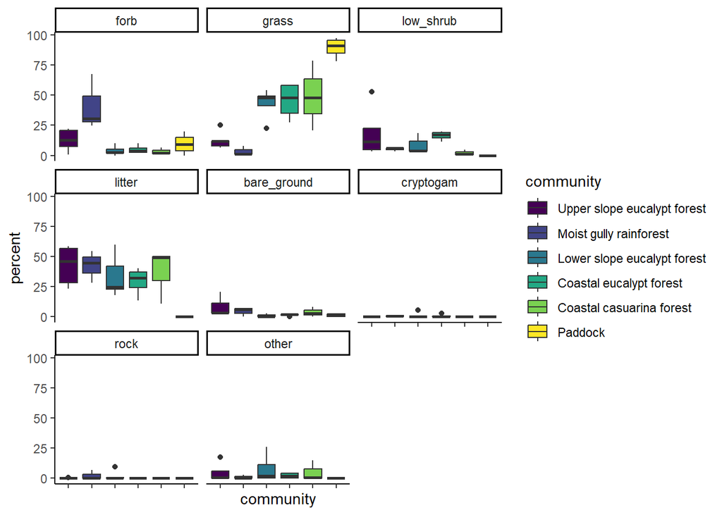

```r
  # remove white spaces in names so can work easily in ggplot
biometric_data2 <- clean_names(biometric_data) %>%
  # convert percentages to 0-100
  mutate(across(3:13, ~ .x * 100)) %>%
  # order the factors (by apperance) to match the table colour palette
  mutate(community = as_factor(community))

# break into ground cover data and convert to long format for graphing
cover <- select(biometric_data2, -c(11:16)) %>%
  pivot_longer(cols = 3:10, names_to = "feature", values_to = "percent") %>%
  mutate(feature = as_factor(feature))

# create box plot for cover
ggplot(cover) +
  geom_boxplot(aes(community, percent, fill = community)) +
  scale_fill_viridis_d() +
  facet_wrap(~feature) +
  theme_classic() +
  theme(axis.text.x=element_blank())
```

Good. We can see there are consistently low values for cryptogam, rock and bare ground, so let’s remove those to make the others easier to read.

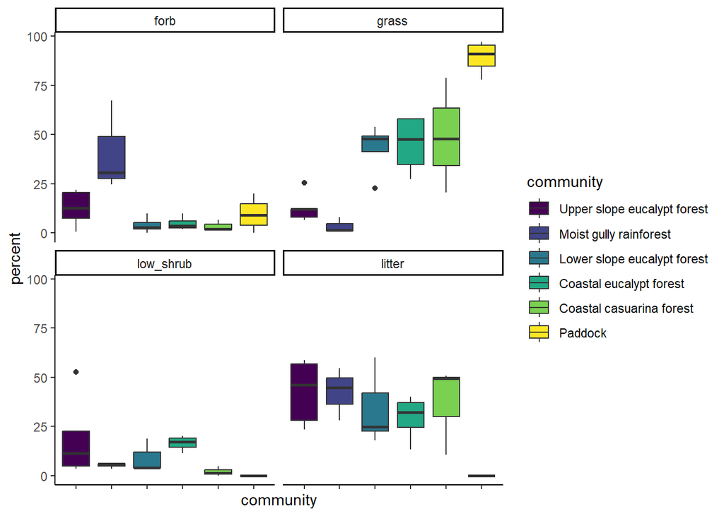

```r
cover2 <- cover %>%
  filter(feature %in% c("cover", "forb", "grass", "litter", "low_shrub"))

# create box plot for cover
ggplot(cover2) +
  geom_boxplot(aes(community, percent, fill = community)) +
  scale_fill_viridis_d() +
  facet_wrap(~feature) +
  theme_classic() +
  theme(axis.text.x=element_blank())
```

Now let’s look at the mid and overstory cover, plus the combined mid and overstory (called in the plot ‘cover’). This gives us an indication of how much light will get through to the floor.

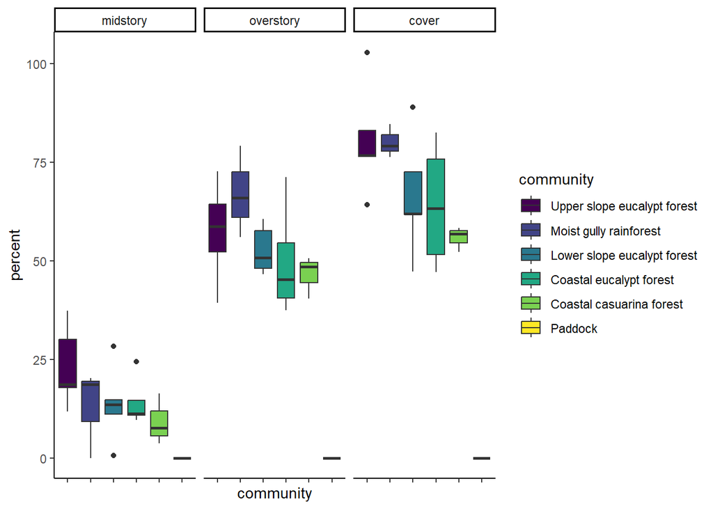

```r
# break into tree cover data and convert to long format for graphing
tree <- select(biometric_data2, -c(3:10, 14:16)) %>%
  pivot_longer(cols = 3:5, names_to = "feature", values_to = "percent") %>%
  mutate(feature = as_factor(feature))

# create box plot for cover
ggplot(tree) +
  geom_boxplot(aes(community, percent, fill = community)) +
  scale_fill_viridis_d() +
  facet_wrap(~feature) +
  theme_classic() +
  theme(axis.text.x=element_blank())
```

Now let’s look at the count data: trees, trees with hollows and length of CWD.

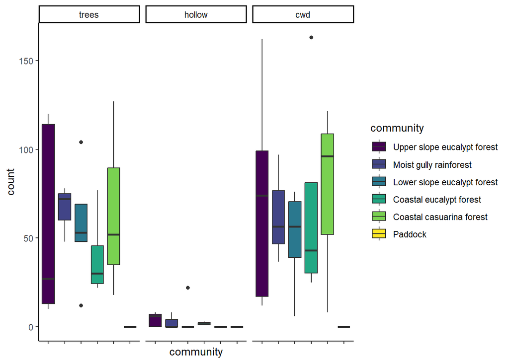

```r
# break into cover data and convert to long format for graphing
count <- select(biometric_data2, -c(3:13)) %>%
  pivot_longer(cols = 3:5, names_to = "feature", values_to = "count") %>%
  mutate(feature = as_factor(feature))

# create box plot for count
ggplot(count) +
  geom_boxplot(aes(community, count, fill = community)) +
  scale_fill_viridis_d() +
  facet_wrap(~feature) +
  theme_classic() +
  theme(axis.text.x=element_blank())
```

And we’ll calculate the following summary statistics for all features: mean and standard deviation.

```r
summary_stats <- biometric_data %>% clean_names() %>%
  pivot_longer(cols = 3:16, names_to = "feature", values_to = "value") %>%
  group_by(community, feature) %>%
  summarise(mean = mean(value),
            sd = sd(value)) %>%
  pivot_wider(names_from = 2, values_from = 3:4) %>%
  sjmisc::rotate_df(cn=TRUE) %>% slice(-1) %>%
  rownames_to_column() %>%
  rename("Stat" = 1) %>%
  separate_wider_delim(Stat, "_", names = c("Stat", "Variable"),
                       too_many = "merge") %>%
  arrange(Variable) %>%
  mutate_at(c(3:8), as.numeric)

summary_stats_table <- gt(summary_stats) %>%
  # change font size
  tab_style(style = cell_text(size = px(12)), locations = cells_body(!1)) %>%
  # add header
  tab_header(title = "Biometric data summary statistics",
             subtitle = "ENVS2018 Student data Kioloa 2023") %>%
  # add source footnote
  tab_source_note(source_note = md("Note: paddock data derived from 2022")) %>%
  # drop trailing zeros
  fmt_number(drop_trailing_zeros = TRUE) %>%
  # format percentages to display %
  fmt_percent(rows = c(1,3,5,9,11,15,17,19,21,23,25), decimals = 1) %>%
    # add column colours
  tab_style(style = cell_fill(color = "#44015433"),
    locations = cells_body(columns = 8)) %>%
  tab_style(style = cell_fill(color = "#41448733"),
    locations = cells_body(columns = 6)) %>%
  tab_style(style = cell_fill(color = "#22A88433"),
    locations = cells_body(columns = 4)) %>%
  tab_style(style = cell_fill(color = "#7AD15133"),
    locations = cells_body(columns = 5)) %>%
  tab_style(style = cell_fill(color = "#FDE72533"),
    locations = cells_body(columns = 3)) %>%
  tab_style(style = cell_fill(color = "#EAEAEA"),
    locations = cells_body(columns = 7)) %>%
  # arrange columsn per other tables
  cols_move(columns = 8, after = 2) %>%
  cols_move(columns = 6, after = 3) %>%
  cols_move(columns = 5, after = 4) %>%
  cols_move(columns = 3, after = 7) %>%
  cols_move(columns = 4, after = 6) %>%
  cols_move_to_end(Paddock)

summary_stats_table
```

Biometric data summary statistics

ENVS2018 Student data Kioloa 2023

| Stat | Variable | Upper slope eucalypt forest | Moist gully rainforest | Coastal eucalypt forest | Lower slope eucalypt forest | Coastal casuarina forest | Paddock |
| --- | --- | --- | --- | --- | --- | --- | --- |
| mean | bare_ground | 8.1% | 4.4% | 1.7% | 0.8% | 3.6% | 1.2% |
| sd | bare_ground | 0.08 | 0.04 | 0.01 | 0.01 | 0.04 | 0.01 |
| mean | cover | 80.6% | 80.1% | 64.1% | 66.5% | 55.8% | 0.0% |
| sd | cover | 0.14 | 0.04 | 0.17 | 0.15 | 0.03 | 0 |
| mean | cryptogam | 0.0% | 0.7% | 0.7% | 1.1% | 0.0% | 0.0% |
| sd | cryptogam | 0 | 0.01 | 0.01 | 0.02 | 0 | 0 |
| mean | cwd | 72.8 | 63.38 | 68.5 | 49.62 | 75.13 | 0 |
| sd | cwd | 62.16 | 30.76 | 64.2 | 28.28 | 59.51 | 0 |
| mean | forb | 12.7% | 40.9% | 4.8% | 4.0% | 3.3% | 9.5% |
| sd | forb | 0.09 | 0.23 | 0.04 | 0.04 | 0.03 | 0.09 |
| mean | grass | 12.8% | 3.3% | 45.2% | 43.1% | 49.1% | 89.2% |
| sd | grass | 0.07 | 0.04 | 0.15 | 0.12 | 0.29 | 0.09 |
| mean | hollow | 4.2 | 2.67 | 1.75 | 4.4 | 0 | 0 |
| sd | hollow | 3.9 | 4.62 | 0.96 | 9.84 | 0 | 0 |
| mean | litter | 42.5% | 42.4% | 29.3% | 33.5% | 36.9% | 0.0% |
| sd | litter | 0.16 | 0.13 | 0.12 | 0.17 | 0.23 | 0 |
| mean | low_shrub | 18.9% | 5.1% | 16.3% | 8.5% | 2.0% | 0.0% |
| sd | low_shrub | 0.2 | 0.02 | 0.04 | 0.07 | 0.02 | 0 |
| mean | midstory | 23.2% | 13.0% | 14.2% | 13.7% | 9.2% | 0.0% |
| sd | midstory | 0.1 | 0.11 | 0.07 | 0.1 | 0.06 | 0 |
| mean | other | 4.8% | 0.9% | 2.0% | 7.9% | 5.1% | 0.0% |
| sd | other | 0.07 | 0.02 | 0.02 | 0.11 | 0.08 | 0 |
| mean | overstory | 57.5% | 67.1% | 49.8% | 52.8% | 46.6% | 0.0% |
| sd | overstory | 0.13 | 0.12 | 0.15 | 0.06 | 0.05 | 0 |
| mean | rock | 0.1% | 2.2% | 0.0% | 2.0% | 0.0% | 0.0% |
| sd | rock | 0 | 0.04 | 0 | 0.04 | 0 | 0 |
| mean | trees | 56.8 | 66 | 39.75 | 57.2 | 65.67 | 0 |
| sd | trees | 55.37 | 15.87 | 25.45 | 33.45 | 55.77 | 0 |

Note: paddock data derived from 2022

# 4 **Bird surveys**

We conducted expert bird surveys of all the plots. The observer recorded all birds seen and heard in a five-minute period in the following distance categories: <25m, 25-50m, 50-100m, 100+m and overhead. We also asked you to estimate how many species you could identify during the survey.

Let’s start by visualising and summarising the data to get our heads around it.

```r
# read in the data and clean names
birds_expert <- read_excel("data/ENVS2018 kioloa bird data 2023.xlsx", sheet = 1) %>%
  clean_names()

birds_student <- read_excel("data/ENVS2018 kioloa bird data 2023.xlsx", sheet = 4) %>%
  clean_names()
```